# Índice de discriminación a los estudiantes de UTEC en 2022-2

# **Introducción**

## *Relevancia*

La discriminación es un tema controversial que se ha intentado erradicar desde hace varios años. Existen casos de discriminación en casi todos los lugares públicos y privados del mundo y la universidad UTEC no es una excepción.

# **Datos**

## *Proceso de recolección de datos*

El proceso de recolección de datos se llevó a cabo mediante una encuesta por Google Forms. Dicha encuesta cuenta con 14 preguntas (variables) y fue enviada aleatoriamente a los alumnos de la institución por correo electrónico. También se realizaron encuestas presencialmente en el campus.

## *Población, muestra y muestreo*

La población del estudio es la comunidad de estudiantes UTEC presentes en el ciclo 2022-2. La unidad muestral es el alumno UTEC que se encuentra matriculado en el ciclo 2022-2. El tamaño de la muestra es de 214 personas. El método de muestreo utilizado fue muestreo aleatorio simple.

## *Variables*

- Edad:
  - Tipo: Cuantitativa discreta.
  - Restricciones: Debe ser un número entero no negativo.
- Ciclo:
  - Tipo: Cuantitativa discreta.
  - Restricciones: Debe ser un número entero no negativo entre 1 y 10.
- Estatura:
  - Tipo: Cuantitativa continua.
  - Restricciones: Debe ser un número decimal no negativo y en metros.
- Peso:
  - Tipo: Cuantitativa continua.
  - Restricciones: Debe ser un número entero no negativo y en kilogramos.
- Sexo:
  - Tipo: Cualitativa nominal.
  - Restricciones: Debe ser hombre o mujer.
- Distrito de residencia:
  - Tipo: Cualitativa nominal.
  - Restricciones: Debe ser un distrito ingresado por la persona o de la siguiente lista:

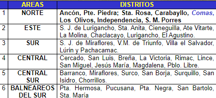

- Clase social:
  - Tipo: Cualitativa Jerárquica.
  - Restricciones: Debe ser clase alta, clase media alta, clase media, clase media baja, clase baja.
- Haber sufrido discriminación:
  - Tipo: Cualitativa nominal.
  - Restricciones: Debe ser sí o no.
- Forma de discriminación:
  - Tipo: Cualitativa nominal.
  - Restricciones: Debe ser verbal, física, acto de exclusión, u otra forma ingresada por la persona.
- Motivo del acto discriminatorio:
  - Tipo: Cualitativa nominal.
  - Restricciones: Debe ser un motivo ingresado por la persona o de la siguiente lista:
    - Lugar de origen
    - Color de piel
    - Estatus económico
    - Estatus social
    - Sexo
    - Aspecto físico
    - Lugar de residencia
    - Discapacidad
    - Religión
- Apoyo externo:
  - Tipo: Cualitativa nominal.
  - Restricciones: Debe ser sí o no.
- Grado de satisfacción con amigos en UTEC:
  - Tipo: Cualitativa Jerárquica.
  - Restricciones: Debe ser un número entero positivo entre 1 y 5.
- Cree la persona que la discriminación dentro de la universidad puede llevar al afectado a un mal rendimiento académico:
  - Tipo: Cualititativa nominal.
  - Restricciones: Debe ser sí o no.
- Importancia de concientizar acerca de la discriminación:
  - Tipo: Cualititativa jerárquica.
  - Restricciones: Debe ser un número entero positivo entre 1 y 5.

## *Limpieza de base de datos*

A continuación el proceso de limpieza de datos:

```r
library(readr)
library(dplyr)
library(modeest)
c <- read_csv("Encuestas - Respuestas de formulario 1 (2).csv", col_types = "nnnncccccccncn")
```

```r
c <- rename(c, Edad = "¿Cuántos años tienes? Responder solo con números (ej: 24)", Ciclo = "¿En qué ciclo estás?", Estatura = "¿Cuánto mides? Responder en metros", Peso = "¿Cuánto pesas?  Responder en kg", Sexo = "¿Con que género te identificas?", Distrito = "¿De qué distrito eres?", ClaseSocial = "¿De qué clase social te consideras?", HaberSufridoDiscriminacion = "¿Alguna vez has sido discrimid@?", Formadediscriminacion = "¿Mediante que forma ocurrió la conducta discriminatoria?", MotivodelActoDiscriminatorio = "¿A qué cree que se debió el acto de discriminación que sufrió?", ApoyoExterno = "¿Has recibido apoyo externo frente a un caso de discriminación?", GradoSatisfaccionAmigos = "¿Del 1 al 5 cuál es el grado de satisfacción que tienes con tus compañeros en la UTEC?", AfectaRendimiento = "¿Sientes que la discriminación dentro de la universidad puede llevar al afectado a un mal rendimiento académico?", Concientizar = "¿Del 1 al 5 qué tan importante te parece concientizar acerca de la discriminación?") -> limpio
```

```r
names(limpio)
```

```
##  [1] "Edad"                         "Ciclo"
##  [3] "Estatura"                     "Peso"
##  [5] "Sexo"                         "Distrito"
##  [7] "ClaseSocial"                  "HaberSufridoDiscriminacion"
##  [9] "Formadediscriminacion"        "MotivodelActoDiscriminatorio"
## [11] "ApoyoExterno"                 "GradoSatisfaccionAmigos"
## [13] "AfectaRendimiento"            "Concientizar"
```

```r
unique(limpio$Estatura)
```

```
##  [1]   1.68   1.80   1.57   1.53   1.62   1.70 173.00   1.65   1.63   1.69
## [11]   1.64   1.81   1.97   1.78   1.59   1.54   1.76   1.00   1.95   1.77
## [21] 178.00   1.87   1.75  16.00 157.00 163.00   1.66 164.00 169.00  60.00
## [31]   1.50 156.00   1.58 167.00 183.00 154.00 170.00 153.00   1.67   1.71
## [41]   1.72   1.74   1.73   1.56   1.85   1.61   1.79   1.60   1.55
```

```r
limpio %>% mutate(Estatura =
                          ifelse(Estatura == 173.00, 1.73,
                          ifelse(Estatura == 1.00, 1.60,
                          ifelse(Estatura == 178.00, 1.78,
                          ifelse(Estatura == 157.00, 1.57,
                          ifelse(Estatura == 163.00, 1.63,
                          ifelse(Estatura == 164.00, 1.64,
                          ifelse(Estatura == 169.00, 1.69,
                          ifelse(Estatura == 60.00, 1.60,
                          ifelse(Estatura == 156.00, 1.56,
                          ifelse(Estatura == 167.00, 1.67,
                          ifelse(Estatura == 183.00, 1.83,
                          ifelse(Estatura == 154.00, 1.54,
                          ifelse(Estatura == 170.00, 1.70,
                          ifelse(Estatura == 153.00, 1.53,
                          ifelse(Estatura == 16.00, 1.60, Estatura
                          )))))))))))))))) -> limpio
```

```r
unique(limpio$Peso)
```

```
##  [1]  58.00  60.00  80.00  49.48  55.00  70.00  42.00  89.00  61.00  56.00
## [11]  78.00 115.00  63.00  65.00  57.00  52.00  76.00  72.00  68.00  92.00
## [21]  66.00  87.00  71.00  50.00  82.00  45.00  53.00  88.00  54.00  90.00
## [31]  48.00  86.00  98.00  75.00  85.00  77.00  81.00  74.00  69.00  67.00
## [41]  79.00  59.00  95.00  84.00  83.00  73.00  62.00  91.00
```

```r
unique(limpio$Distrito)
```

```
##  [1] "Surquillo"               "San Juan de Lurigancho"
##  [3] "Miraflores"              "Jesús María"
##  [5] "Chorrillos"              "Santiago de Surco"
##  [7] "Pueblo Libre"            "Ate Vitarte"
##  [9] "Santa Anita"             "Lurigancho"
## [11] "San Juan de Miraflores"  "San Borja"
## [13] "San Isidro"              "ayacucho"
## [15] "Independencia"           "San Miguel"
## [17] "Barranco"                "San Luis"
## [19] "Lurín"                   "Los Olivos"
## [21] "Lima"                    "La Molina"
## [23] "Ancón"                   "Comas"
## [25] "Lince"                   "El Agustino"
## [27] "Magdalena del Mar"       "Pachacamac"
## [29] "Breña"                   "La Victoria"
## [31] "Pucusana"                "Villa El Salvador"
## [33] "Villa María del Triunfo" "San Martín de Porres"
## [35] "Cieneguilla"             "Carabayllo"
## [37] "Rímac"                   "Puente Piedra"
```

```r
limpio %>% mutate(Distrito =
                          ifelse(Distrito == "ayacucho", "Provincia", Distrito
                          )) -> limpio
```

```r
unique(limpio$Distrito)
```

```
##  [1] "Surquillo"               "San Juan de Lurigancho"
##  [3] "Miraflores"              "Jesús María"
##  [5] "Chorrillos"              "Santiago de Surco"
##  [7] "Pueblo Libre"            "Ate Vitarte"
##  [9] "Santa Anita"             "Lurigancho"
## [11] "San Juan de Miraflores"  "San Borja"
## [13] "San Isidro"              "Provincia"
## [15] "Independencia"           "San Miguel"
## [17] "Barranco"                "San Luis"
## [19] "Lurín"                   "Los Olivos"
## [21] "Lima"                    "La Molina"
## [23] "Ancón"                   "Comas"
## [25] "Lince"                   "El Agustino"
## [27] "Magdalena del Mar"       "Pachacamac"
## [29] "Breña"                   "La Victoria"
## [31] "Pucusana"                "Villa El Salvador"
## [33] "Villa María del Triunfo" "San Martín de Porres"
## [35] "Cieneguilla"             "Carabayllo"
## [37] "Rímac"                   "Puente Piedra"
```

```r
unique(limpio$Formadediscriminacion)
```

```
## [1] NA
## [2] "Verbal"
## [3] "Física"
## [4] "TA"
## [5] "Exclusión"
## [6] "No me permitieron entrar a un establecimiento."
## [7] "Mediante insultos"
## [8] "Mediante redes sociales"
```

```r
limpio %>% mutate(Formadediscriminacion =
                          ifelse(Formadediscriminacion == "TA", NA,
                          ifelse(Formadediscriminacion == "Mediante insultos", "Verbal",
                          ifelse(Formadediscriminacion == "No me permitieron entrar a un establecimiento.", "Exclusión", Formadediscriminacion
                          )))) -> limpio
```

```r
unique(limpio$MotivodelActoDiscriminatorio)
```

```
##  [1] NA                     "Lugar de origen"      "Color de piel"
##  [4] "Aspecto físico"       "Religión"             "Estatus social"
##  [7] "Estatus económico"    "Enfermo"              "Orientación sexual"
## [10] "Sexo"                 "Lugar de residencia"  "Debido a mi altura"
## [13] "Fue por mi sobrepeso" "Debido a un embarazo" "Orientacion sexual"
## [16] "Orientación Sexual"
```

```r
limpio %>% mutate(MotivodelActoDiscriminatorio =
                          ifelse(MotivodelActoDiscriminatorio == "Enfermo", "Enfermedad",
                          ifelse(MotivodelActoDiscriminatorio == "Fue por mi sobrepeso", "Aspecto físico",
                          ifelse(MotivodelActoDiscriminatorio == "Debido a un embarazo", "Embarazo",
                          ifelse(MotivodelActoDiscriminatorio == "Orientacion sexual", "Orientación sexual",
                          ifelse(MotivodelActoDiscriminatorio == "Orientación Sexual", "Orientación sexual",
                          ifelse(MotivodelActoDiscriminatorio == "Peso", "Aspecto físico",
                          ifelse(MotivodelActoDiscriminatorio == "Aspecto Físico", "Aspecto físico",
                          ifelse(MotivodelActoDiscriminatorio == "Color de piel", "Aspecto físico",
                          ifelse(MotivodelActoDiscriminatorio == "Debido a mi altura", "Aspecto físico", MotivodelActoDiscriminatorio
                          )))))))))) -> limpio
```

```r
str(limpio)
```

```
## tibble [214 x 14] (S3: tbl_df/tbl/data.frame)
##  $ Edad                        : num [1:214] 17 20 17 19 19 19 21 18 19 18 ...
##  $ Ciclo                       : num [1:214] 2 5 2 5 3 4 3 4 4 3 ...
##  $ Estatura                    : num [1:214] 1.68 1.68 1.8 1.57 1.53 1.8 1.62 1.7 1.62 1.73 ...
##  $ Peso                        : num [1:214] 58 60 80 49.5 60 ...
##  $ Sexo                        : chr [1:214] "Hombre" "Hombre" "Hombre" "Mujer" ...
##  $ Distrito                    : chr [1:214] "Surquillo" "San Juan de Lurigancho" "Miraflores" "San Juan de Lurigancho" ...
##  $ ClaseSocial                 : chr [1:214] "Clase media" "Clase baja" "Clase media" "Clase baja" ...
##  $ HaberSufridoDiscriminacion  : chr [1:214] "No" "No" "Sí" "No" ...
##  $ Formadediscriminacion       : chr [1:214] NA NA "Verbal" NA ...
##  $ MotivodelActoDiscriminatorio: chr [1:214] NA NA "Lugar de origen" NA ...
##  $ ApoyoExterno                : chr [1:214] NA NA "Si" NA ...
##  $ GradoSatisfaccionAmigos     : num [1:214] 4 5 4 3 5 5 1 4 4 4 ...
##  $ AfectaRendimiento           : chr [1:214] "Si" "Si" "Si" "Si" ...
##  $ Concientizar                : num [1:214] 5 5 5 5 5 5 5 5 5 5 ...
```

```r
limpio -> base_de_datos
```

```r
str(base_de_datos)
```

```
## tibble [214 x 14] (S3: tbl_df/tbl/data.frame)
##  $ Edad                        : num [1:214] 17 20 17 19 19 19 21 18 19 18 ...
##  $ Ciclo                       : num [1:214] 2 5 2 5 3 4 3 4 4 3 ...
##  $ Estatura                    : num [1:214] 1.68 1.68 1.8 1.57 1.53 1.8 1.62 1.7 1.62 1.73 ...
##  $ Peso                        : num [1:214] 58 60 80 49.5 60 ...
##  $ Sexo                        : chr [1:214] "Hombre" "Hombre" "Hombre" "Mujer" ...
##  $ Distrito                    : chr [1:214] "Surquillo" "San Juan de Lurigancho" "Miraflores" "San Juan de Lurigancho" ...
##  $ ClaseSocial                 : chr [1:214] "Clase media" "Clase baja" "Clase media" "Clase baja" ...
##  $ HaberSufridoDiscriminacion  : chr [1:214] "No" "No" "Sí" "No" ...
##  $ Formadediscriminacion       : chr [1:214] NA NA "Verbal" NA ...
##  $ MotivodelActoDiscriminatorio: chr [1:214] NA NA "Lugar de origen" NA ...
##  $ ApoyoExterno                : chr [1:214] NA NA "Si" NA ...
##  $ GradoSatisfaccionAmigos     : num [1:214] 4 5 4 3 5 5 1 4 4 4 ...
##  $ AfectaRendimiento           : chr [1:214] "Si" "Si" "Si" "Si" ...
##  $ Concientizar                : num [1:214] 5 5 5 5 5 5 5 5 5 5 ...
```

# **Análisis descriptivo**

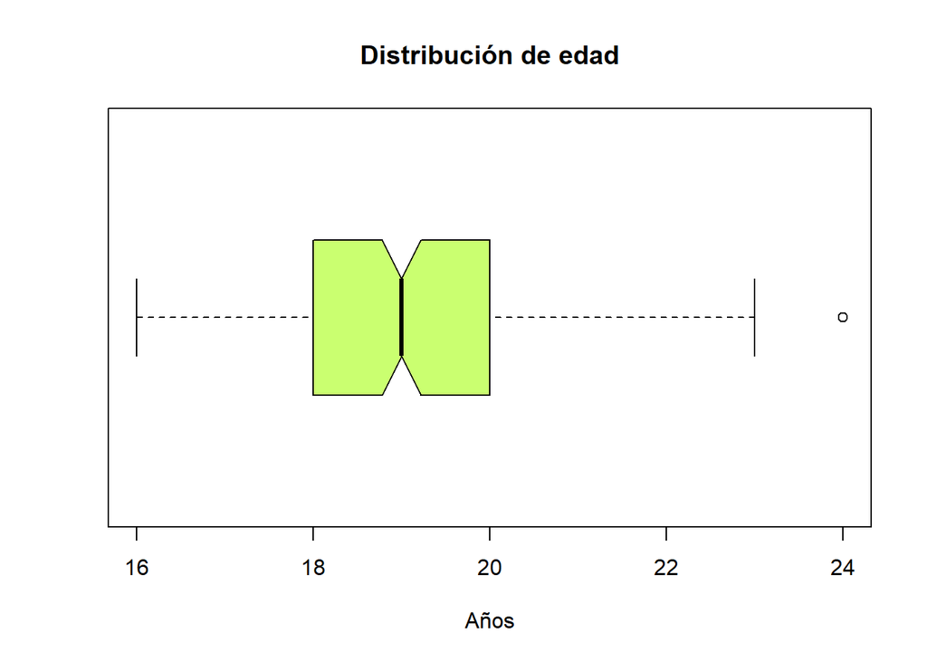

```r
boxplot(base_de_datos$Edad,col="darkolivegreen1", main = "Distribución de edad", xlab = "Años", notch = TRUE, horizontal = TRUE)
```

- Mediante el boxplot se pueden analizar los cuantiles y valores extremos de una variable cuantitativa. Como se puede observar, la escala va de 2 años, 24 años es un valor atípico y 16 años el valor mínimo. Además, la mediana es 19 años, el primer cuartil (25%) es 18 años y el tercero (75%) es 20 años.

```r
round(mean(base_de_datos$Edad, na.rm=TRUE),2)
```

```
## [1] 18.98
```

```r
median(base_de_datos$Edad, na.rm=TRUE)
```

```
## [1] 19
```

```r
mfv(base_de_datos$Edad, na_rm=TRUE)
```

```
## [1] 18
```

```r
min(base_de_datos$Edad, na.rm = TRUE)
```

```
## [1] 16
```

```r
max(base_de_datos$Edad, na.rm = TRUE)
```

```
## [1] 24
```

```r
range(base_de_datos$Edad, na.rm = TRUE)
```

```
## [1] 16 24
```

```r
quantile(base_de_datos$Edad, c(0.25, 0.5, 0.75, 1))
```

```
##  25%  50%  75% 100%
##   18   19   20   24
```

```r
round(var(base_de_datos$Edad, na.rm = TRUE),2)
```

```
## [1] 2.73
```

```r
round(sd(base_de_datos$Edad, na.rm = TRUE),2)
```

```
## [1] 1.65
```

```r
round(sd(base_de_datos$Edad, na.rm = TRUE)/mean(base_de_datos$Edad, na.rm=TRUE),2)
```

```
## [1] 0.09
```

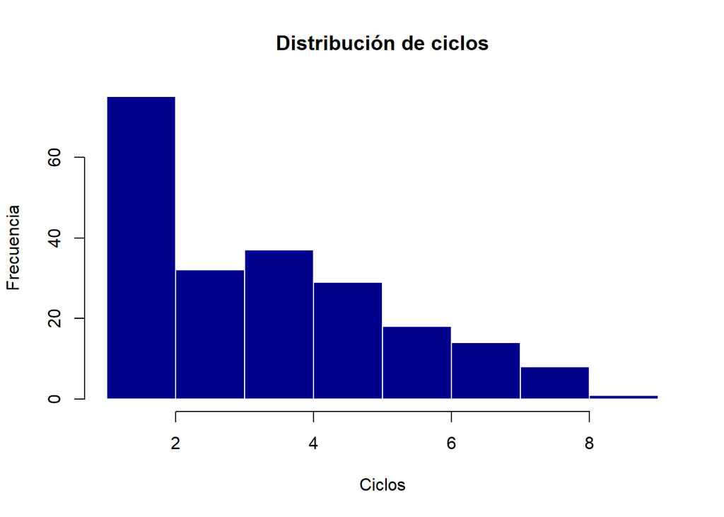

  ```r
  hist(base_de_datos$Ciclo,col="blue4", main = "Distribución de ciclos", xlab = "Ciclos", ylab = "Frecuencia", border = "white")
  ```

- Con el histograma se puede evaluar la distribución de los datos de la variable ciclo. Se observa que la mayoría de los encuestados se encuentran en los ciclos 1 y 2, mientras que en el ciclo 9 hay máximo 5 personas. Los encuestados del noveno (9) y octavo (8) ciclo explican la media y mediana.

```r
round(mean(base_de_datos$Ciclo))
```

```
## [1] 4
```

```r
round(median(base_de_datos$Ciclo))
```

```
## [1] 4
```

```r
mfv(base_de_datos$Ciclo, na_rm=TRUE)
```

```
## [1] 2
```

```r
min(base_de_datos$Ciclo, na.rm = TRUE)
```

```
## [1] 1
```

```r
max(base_de_datos$Ciclo, na.rm = TRUE)
```

```
## [1] 9
```

```r
range(base_de_datos$Ciclo, na.rm = TRUE )
```

```
## [1] 1 9
```

```r
round(quantile(base_de_datos$Ciclo, c(0.25, 0.5, 0.75, 1)))
```

```
##  25%  50%  75% 100%
##    2    4    5    9
```

```r
round(var(base_de_datos$Ciclo, na.rm = TRUE),2)
```

```
## [1] 3.72
```

```r
round(sd(base_de_datos$Ciclo, na.rm = TRUE),2)
```

```
## [1] 1.93
```

```r
round(sd(base_de_datos$Ciclo, na.rm = TRUE)/mean(base_de_datos$Edad, na.rm=TRUE),2)
```

```
## [1] 0.1
```

- **Estatura:** Los datos se ingresaron en metros. Mediante lo recolectado en el estudio se puede describir de la siguiente manera:
  - **Descriptores numéricos:**
    - La *media* de la estatura es **1.69** metros.
    - La *mediana* es **1.68** metros. Se puede concluir que la distribución es simétrica ya que la estatura es practicamente igual a la mediana.
    - La *moda* de la estatura es **1.7** metros.
    - El *rango* de estatura va de **1.5** a **1.97** metros, siendo 1.5 el mínimo y 1.97 el máximo. El dato 1.5 metros sería un dato atípico.
    - Los *cuantiles* están definidos por: 25%: **1.65**, 50%: **1.68**, 75%: **1.72**, 100%: **1.97**. Esto indica que podría haber un dato atípico en el cuarto cuantil.
    - La *varianza* es **0.01** y la *desviación estándar* **0.07**. Esto indica que los datos no son muy variables. Cabe resaltar que el hecho de que la estatura esté medida en metros influye en la baja varianza y desviación estandar.
    - El *coeficiente de variación* es **0.04** o 4%. Esto indica que los datos son relativamente homogéneos y la media es representativa.
  - **Descriptor gráfico:**

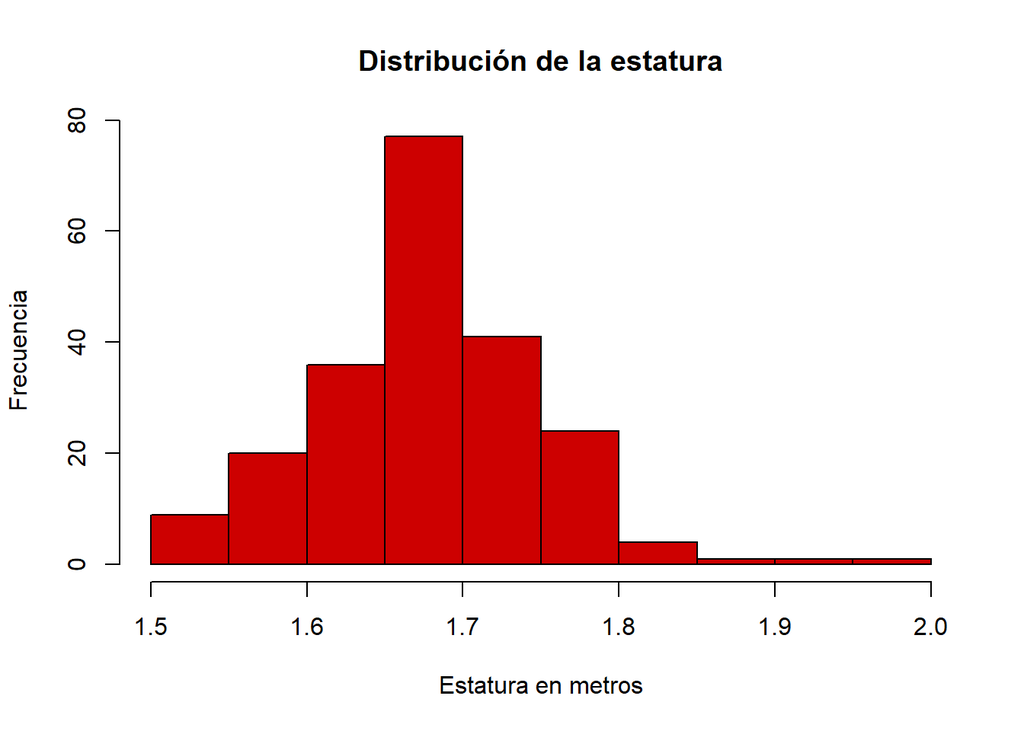

```r
hist(base_de_datos$Estatura,
        main = "Distribución de la estatura",
        ylab = "Frecuencia",
        col = "red3",
        xlab = "Estatura en metros")
```

- Como se puede observar en el histograma, la mayor concentración de datos se encuentra entre 1.6 y 1.7 metros. Además, la distribución es simétrica con algunos datos atípicos hacia la derecha, los cuales se podrían visualizar mejor en un boxplot. Se identifica que la moda de la estatura tiende a los valores de la estatura promedio del varón peruano.

```r
round(mean(base_de_datos$Estatura, na.rm=TRUE),2)
```

```
## [1] 1.69
```

```r
median(base_de_datos$Estatura, na.rm=TRUE)
```

```
## [1] 1.68
```

```r
mfv(base_de_datos$Estatura, na_rm=TRUE)
```

```
## [1] 1.7
```

```r
min(base_de_datos$Estatura, na.rm = TRUE)
```

```
## [1] 1.5
```

```r
max(base_de_datos$Estatura, na.rm = TRUE)
```

```
## [1] 1.97
```

```r
range(base_de_datos$Estatura, na.rm = TRUE)
```

```
## [1] 1.50 1.97
```

```r
quantile(base_de_datos$Estatura, c(0.25, 0.5, 0.75, 1))
```

```
##  25%  50%  75% 100%
## 1.65 1.68 1.72 1.97
```

```r
round(var(base_de_datos$Estatura, na.rm = TRUE),2)
```

```
## [1] 0.01
```

```r
round(sd(base_de_datos$Estatura, na.rm = TRUE),2)
```

```
## [1] 0.07
```

```r
round(sd(base_de_datos$Estatura, na.rm = TRUE)/mean(base_de_datos$Estatura, na.rm=TRUE),2)
```

```
## [1] 0.04
```

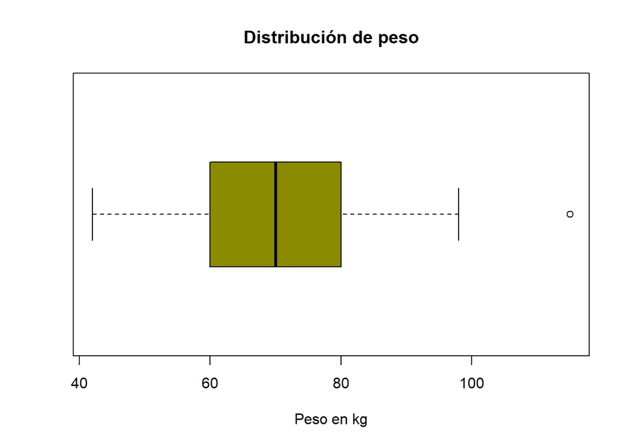

```r
boxplot(base_de_datos$Peso,
        main = "Distribución de peso",
        xlab = "Peso en kg",
        col = "yellow4",
        horizontal = TRUE)
```

```r
round(mean(base_de_datos$Peso, na.rm=TRUE),2)
```

```
## [1] 70.58
```

```r
median(base_de_datos$Peso, na.rm=TRUE)
```

```
## [1] 70
```

```r
mfv(base_de_datos$Peso, na_rm=TRUE)
```

```
## [1] 60
```

```r
min(base_de_datos$Peso, na.rm = TRUE)
```

```
## [1] 42
```

```r
max(base_de_datos$Peso, na.rm = TRUE)
```

```
## [1] 115
```

```r
range(base_de_datos$Peso, na.rm = TRUE)
```

```
## [1]  42 115
```

```r
quantile(base_de_datos$Peso, c(0.25, 0.5, 0.75, 1))
```

```
##  25%  50%  75% 100%
##   60   70   80  115
```

```r
round(sd(base_de_datos$Peso, na.rm = TRUE),2)
```

```
## [1] 12.02
```

```r
round(sd(base_de_datos$Peso, na.rm = TRUE)/mean(base_de_datos$Peso, na.rm=TRUE),2)
```

```
## [1] 0.17
```

- **Sexo:** Mediante lo recolectado en el estudio se puede describir de la siguiente manera:
  - **Descriptores numéricos:**
    - La *moda* del sexo es **hombre**. Esta va de acorde a la media de la estatura la cual es cercana a la estatura promedio del varón peruano.
  - **Descriptor gráfico:**

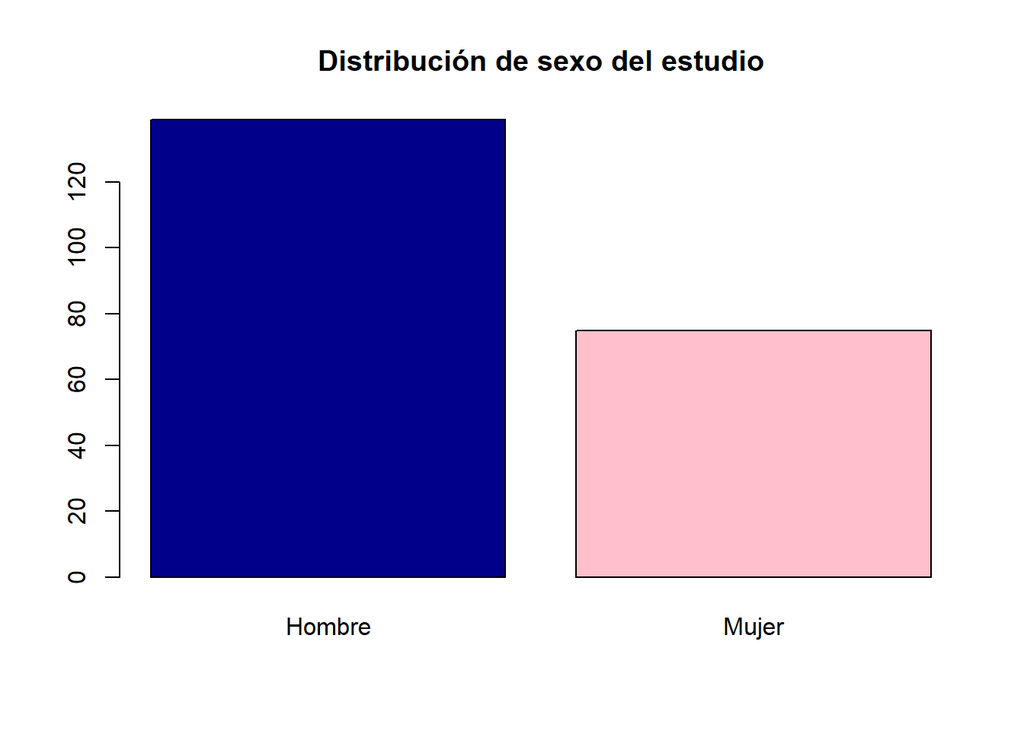

```r
barplot(table(base_de_datos$Sexo), col = c("blue4", "pink"), main = "Distribución de sexo del estudio")
```

- Como se observa en el gráfico de barras de escala 20 años, se concluye que los hombres la cantidad de hombres en el estudio es significativamente mayor que la de mujeres. Se puede entender esta tendencia teniendo en cuenta que el estudio se realizó en la universidad UTEC, la cual cuenta con mayor porcentaje de varones ingresantes.

```r
mfv(base_de_datos$Sexo, na_rm=TRUE)
```

```
## [1] "Hombre"
```

- **Distrito de residencia:** Mediante lo recolectado en el estudio se puede describir de la siguiente manera:
  - **Descriptores numéricos:**
    - La *moda* del distrito de residencia es **San Juan de Lurigancho**, seguido muy de cerca por Miraflores y Santiago de Surco.
  - **Descriptor gráfico:**

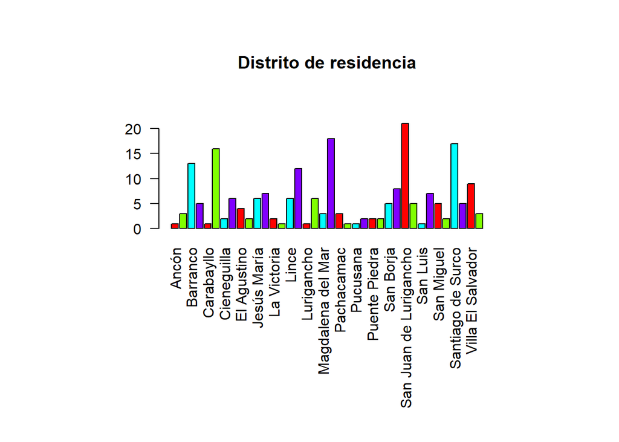

```r
par(mar = c(7, 4, 2, 2) + 5)
barplot(table(base_de_datos$Distrito),main="Distrito de residencia", col=rainbow(4), las = 2)
```

- Como se puede observar en el gráfico de barras los entrevistados tienen a vivir en Santiago de Surco, San Juan de Lurigancho, Miraflores y Chorrillos.

```r
mfv(base_de_datos$Distrito, na_rm=TRUE)
```

```
## [1] "San Juan de Lurigancho"
```

- **Clase social:** Mediante lo recolectado en el estudio se puede describir de la siguiente manera:
  - **Descriptores numéricos:**
    - La *moda* de la clase social es **clase media**.
  - **Descriptor gráfico:**

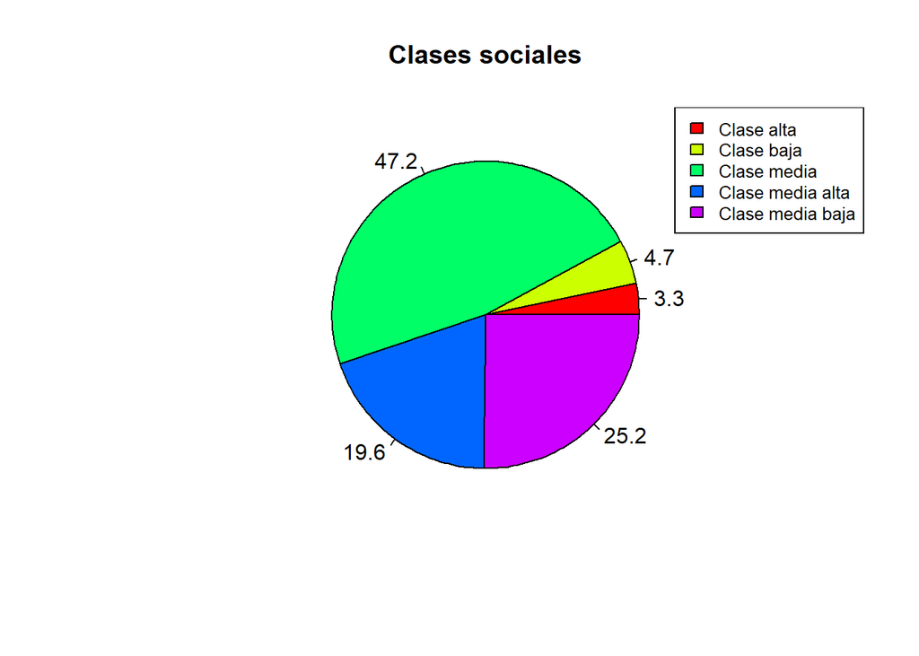

```r
piepercent<- round(100*table(base_de_datos$ClaseSocial)/sum(table(base_de_datos$ClaseSocial)), 1)
pie(table(base_de_datos$ClaseSocial), labels = piepercent, main = "Clases sociales",col = rainbow(length(table(base_de_datos$ClaseSocial))))
legend("topright", c("Clase alta","Clase baja","Clase media","Clase media alta", "Clase media baja"), cex = 0.8, fill = rainbow(length(table(base_de_datos$ClaseSocial))))
```

- Como se puede observar en el piechart, el 47.2% de encuestados se identifica como clase media, el 25.2% como clase media baja, el 19.6% como clase media alta, el 4.7% como clase baja y el 3.3% restante como clase alta. Se ve una tendencia de evitar extremos (clase alta y baja) por parte de los encuestados.

```r
mfv(base_de_datos$ClaseSocial, na_rm=TRUE)
```

```
## [1] "Clase media"
```

- **Haber sufrido discriminación:** La variable que indica si la persona ha sufrido discriminación es una variable cualitativa nominal. Mediante lo recolectado en el estudio se puede describir de la siguiente manera:
  - **Descriptores numéricos:**
    - La *moda* de la variable haber sufrido discriminación es **no**. Este dato puede ser sesgado debido a que algunos encuestados podrían haber mentido por diversos factores personales como vergüenza. Para realizar el análisis se tomarán los datos como representativos.
  - **Descriptor gráfico:**

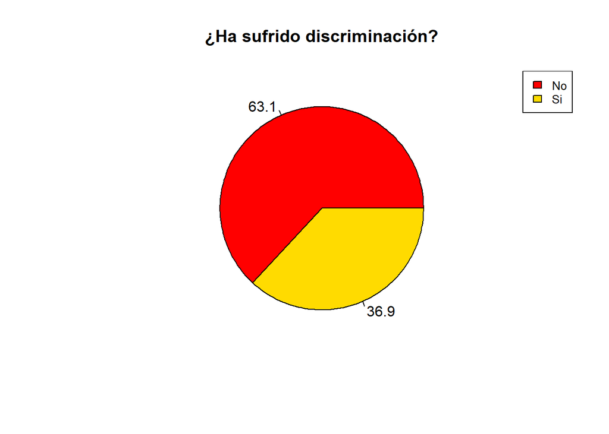

```r
a <- round(100*table(base_de_datos$HaberSufridoDiscriminacion)/sum(table(base_de_datos$HaberSufridoDiscriminacion)), 1)
pie(table(base_de_datos$HaberSufridoDiscriminacion),main="¿Ha sufrido discriminación?", col=rainbow(7), labels = a)
legend("topright", c("No", "Si"), cex = 0.8, fill = rainbow(7))
```

- Como se puede observar en el piechart, el 63.1% de encuestados no han sufrido discriminación mientras que el 36.9% sí.

```r
mfv(base_de_datos$HaberSufridoDiscriminacion, na_rm=TRUE)
```

```
## [1] "No"
```

- **Forma de discriminación:** La variable que describe de qué forma sufrió discriminación el encuestado es una variable cualitativa nominal. Mediante lo recolectado en el estudio se puede describir de la siguiente manera:
  - **Descriptores numéricos:**
    - La *moda* de la variable forma de discriminación es mediante agresión **verbal**.
  - **Descriptor gráfico:**

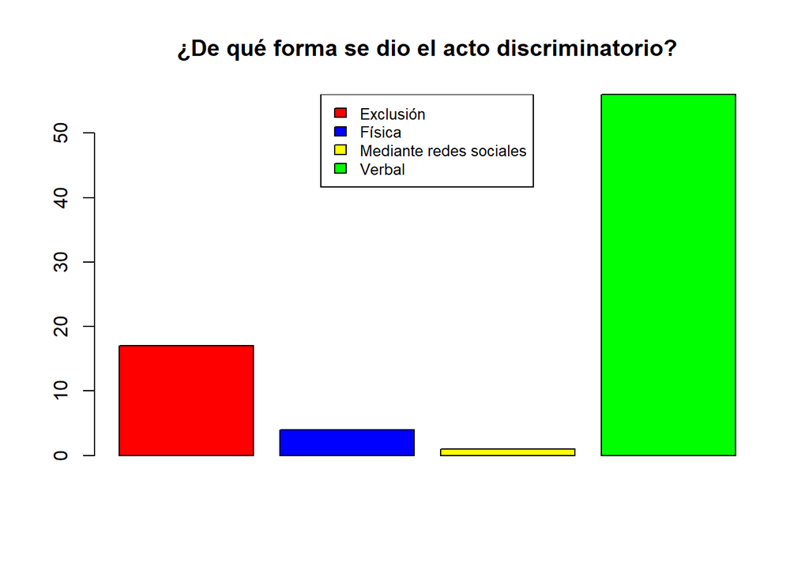

```r
barplot(table(base_de_datos$Formadediscriminacion),main="¿De qué forma se dio el acto discriminatorio?", col = c("Red", "Blue", "Yellow", "Green"), names.arg = "")
legend("top", c("Exclusión", "Física", "Mediante redes sociales", "Verbal"), cex = 0.8, fill = c("Red", "Blue", "Yellow", "Green", "Gray", "Pink"))
```

- En el gráfico de barras se puede observar que la forma más común de discrminación es verbalmente, seguido de exclusión de un espacio o grupo. Los datos arrojados por las encuestas se comprenden ya que la agresión verbal es la más difícil de detectar y sancionar y por lo tanto la más común.

```r
mfv(base_de_datos$Formadediscriminacion, na_rm=TRUE)
```

```
## [1] "Verbal"
```

- **Motivo del acto discriminatorio:** La variable que describe el motivo del acto discriminatorio sufrido por la es una variable cualitativa nominal. Mediante lo recolectado en el estudio se puede describir de la siguiente manera:
  - **Descriptores numéricos:**
    - La *moda* de la variable motivo del acto discriminatorio es **aspecto físico**. Esto se entiende ya que el aspecto físico engloba el color de piel, estatura y peso.
  - **Descriptor gráfico:**

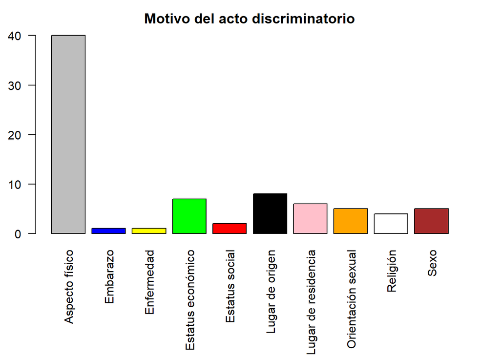

```r
par(mar = c(7, 1, 1, 1) + 1.5)
barplot(table(base_de_datos$MotivodelActoDiscriminatorio),main="Motivo del acto discriminatorio", col = c("Gray", "Blue", "Yellow", "Green", "Red", "Black", "Pink", "Orange", "White", "Brown"), las = 2)
```

- Del gráfico de barras se puede concluir que del total de encuestados que han sido discriminados, la mayoría sufrió por su aspecto físico. Por otro lado, el lugar de origen y el estatus económico también son motivos comunes de discrmininación. Se puede compender la tendencia ya que el aspecto físico de una persona es lo primero que resalta si no se conoce profundamente al individuo.

```r
mfv(base_de_datos$MotivodelActoDiscriminatorio, na_rm=TRUE)
```

```
## [1] "Aspecto físico"
```

- **Apoyo externo:** La variable que si la persona recibió apoyo externo para lidiar con el acto o consecuencias del acto discriminatorio es una variable cualitativa nominal. Mediante lo recolectado en el estudio se puede describir de la siguiente manera:
  - **Descriptores numéricos:**
    - La *moda* de la variable apoyo externo es **no**. Esta tendencia es entendible debido a la vergüenza o miedo que sufren las personas afectadas por algún acto discriminatorio y la poca importancia que algunas autoridades le otorgan al tema.
  - **Descriptor gráfico:**

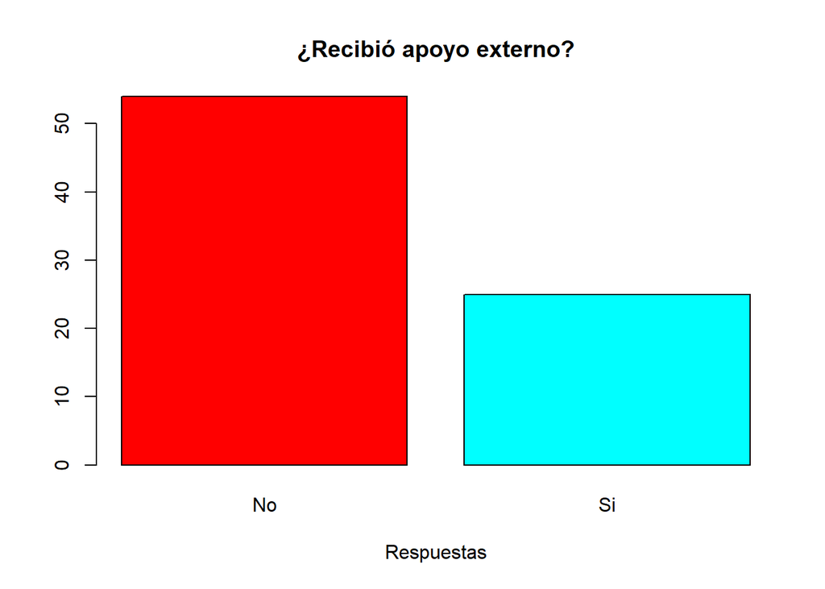

```r
barplot(table(base_de_datos$ApoyoExterno),xlab="Respuestas",main="¿Recibió apoyo externo?", col=rainbow(2))
```

- Como se puede observar en la gráfica, 54 encuestados no recibieron apoyo externo al ser discriminados mientras que 25 sí.

```r
mfv(base_de_datos$ApoyoExterno, na_rm=TRUE)
```

```
## [1] "No"
```

- **Grado de satisfacción con amigos en UTEC:** La variable que indica el grado de satisfacción que tiene el encuestado con sus amistades dentro de UTEC es una variable cualitativa jerárquica. Los valores van entre 1 (min) y 5 (max). Mediante lo recolectado en el estudio se puede describir de la siguiente manera:
  - **Descriptores numéricos:**
    - La *moda* es **4**.
    - El *rango* va de **1** a **5**.
  - **Descriptor gráfico:**

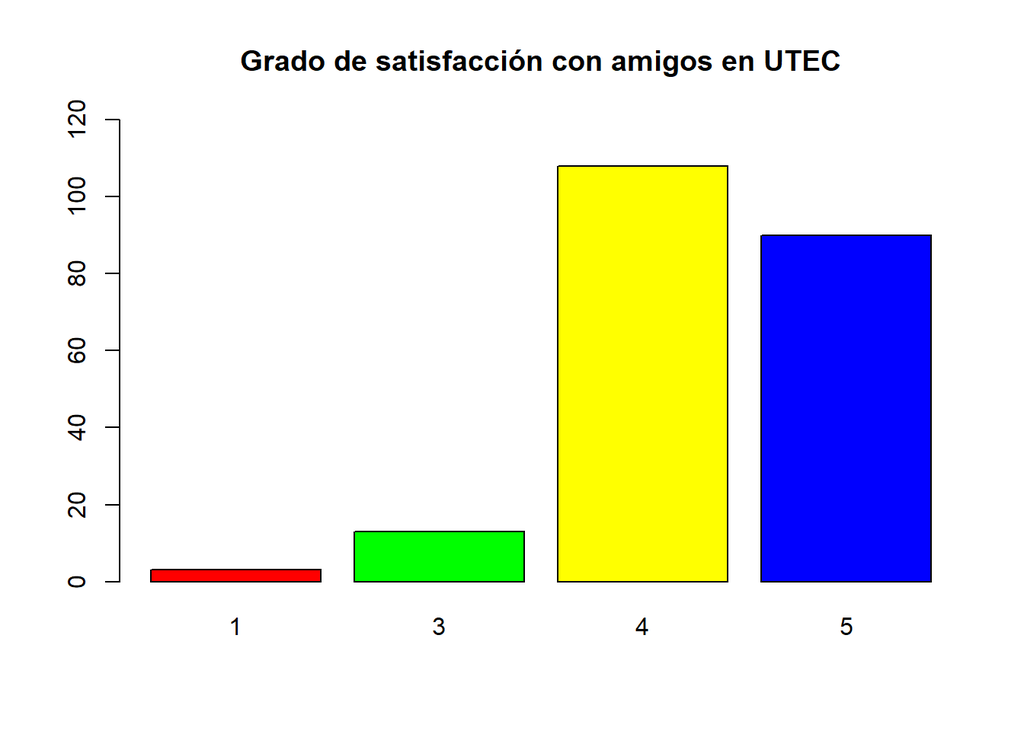

```r
barplot(table(base_de_datos$GradoSatisfaccionAmigos), col = c("red","green","yellow","blue","orange"), ylim=c(0,120), main = "Grado de satisfacción con amigos en UTEC")
```

- Como se puede observar en el gráfico de barras, la moda de la variable es el grado 4 de satisfacción, es decir, la mayoría de encuestados se encuentran satisfechos con sus amigos en UTEC. Cabe resaltar que no hubo caso en el que se seleccionó el evento 2. Esto se puede explicar frente a la clara tendencia de los encuestados a votar positivamente sus relaciones sociales dentro de UTEC.

```r
mfv(base_de_datos$GradoSatisfaccionAmigos, na_rm=TRUE)
```

```
## [1] 4
```

```r
min(base_de_datos$GradoSatisfaccionAmigos, na.rm=TRUE)
```

```
## [1] 1
```

```r
max(base_de_datos$GradoSatisfaccionAmigos, na.rm=TRUE)
```

```
## [1] 5
```

```r
range(base_de_datos$GradoSatisfaccionAmigos, na.rm=TRUE)
```

```
## [1] 1 5
```

- **Cree la persona que la discriminación dentro de la universidad puede llevar al afectado a un mal rendimiento académico:** La variable que indica si la persona cree que el haber sufrido o sufrir constantemente actos de discriminación puede tener como consecuencia un bajo rendimiento académico es una variable cualitativa nomninal. Mediante lo recolectado en el estudio se puede describir de la siguiente manera:
  - **Descriptores numéricos:**
    - La *moda* de la variable es **sí**. La mayoría de encuestados cree que sufrir abusos discriminatorios sí puede afectar al rendimiento académico.
  - **Descriptor gráfico:**

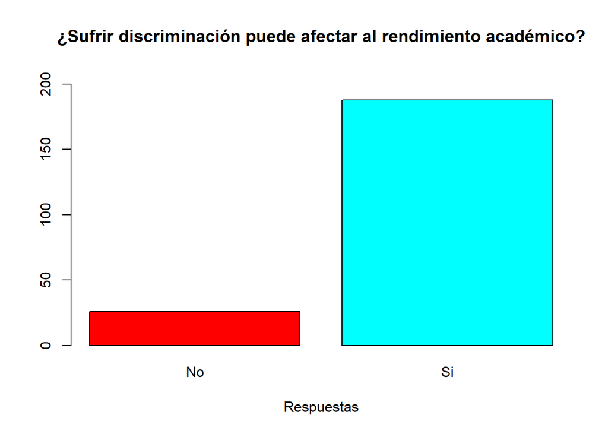

```r
barplot(table(base_de_datos$AfectaRendimiento),xlab="Respuestas",main="¿Sufrir discriminación puede afectar al rendimiento académico?", col=rainbow(2), ylim = c(0,210))
```

- Como se obverva en la gráfica, la mayoría de los encuestados creen que sufrir discriminación sí puede afectar al rendimiento académico. Se puede afirmar que la moda es sí por un margen significativo.

```r
mfv(base_de_datos$AfectaRendimiento)
```

```
## [1] "Si"
```

- **Importancia de concientizar acerca de la discriminación:** Los valores van entre 1(min) y 5(máx), siendo 1 “nada importante” y 5 “muy importante”. Mediante lo recolectado en el estudio se puede describir de la siguiente manera:
  - **Descriptores numéricos:**
    - La *moda* de la variable es **5**. La mayoría de encuestados cree que es muy importante concientizar acerca de la discriminación.
  - **Descriptor gráfico:**

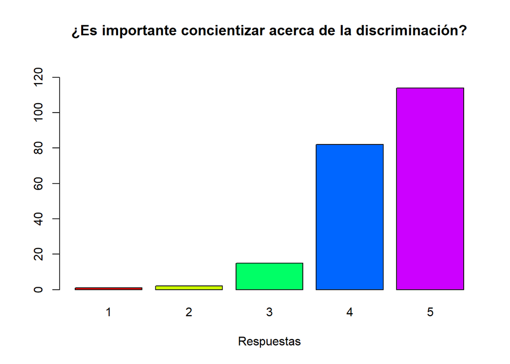

```r
barplot(table(base_de_datos$Concientizar),xlab="Respuestas",main="¿Es importante concientizar acerca de la discriminación?", col=rainbow(5), ylim = c(0,130))
```

- La variable tiene valores entre 1 y 5, siendo 1 totalmente en desacuerdo y 5 totalmente de acuerdo. Como se puede vizualizar en el gráfico de barras, la mayoría de los encuestados está totalmente de acuerdo con que es importante concientizar acerca y en contra de la discriminación.

```r
mfv(base_de_datos$Concientizar)
```

```
## [1] 5
```

## Interacción entre variables

- **Ha sufrido discriminción - Peso:** El peso es un motivo común de discriminación por lo que es viable estudiar la interacción entre ambas variables. Para esto se utiliza el siguiente descriptor gráfico:

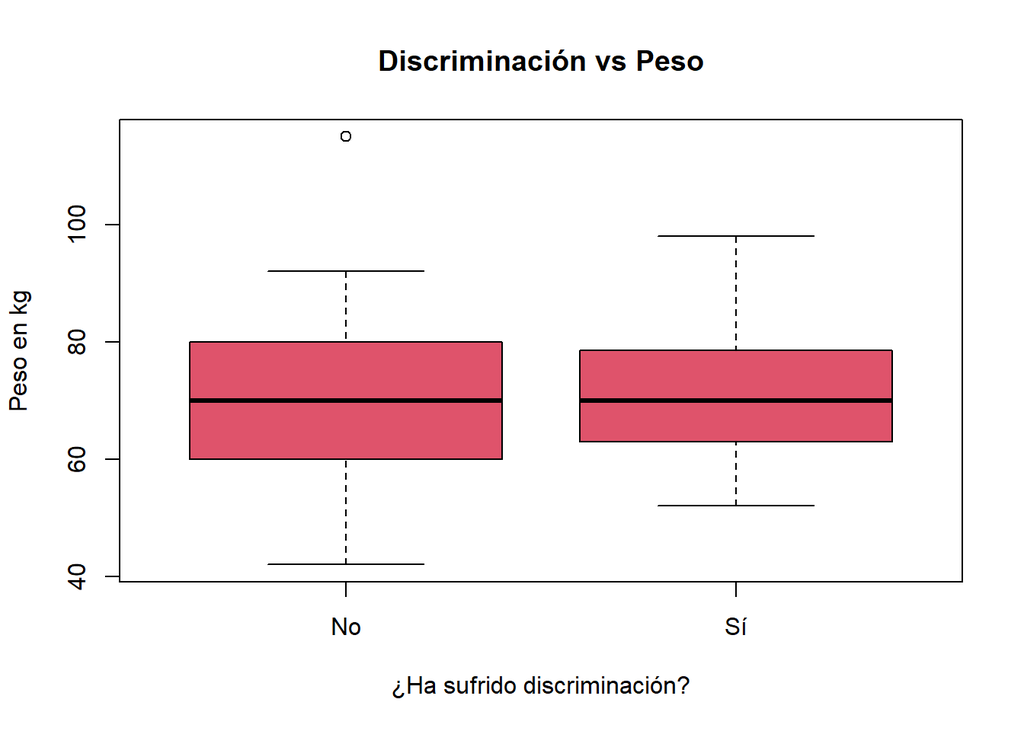

```r
boxplot(base_de_datos$Peso ~ base_de_datos$HaberSufridoDiscriminacion, col = 2,
        main = "Discriminación vs Peso",
        ylab = "Peso en kg",
        xlab = "¿Ha sufrido discriminación?")
```

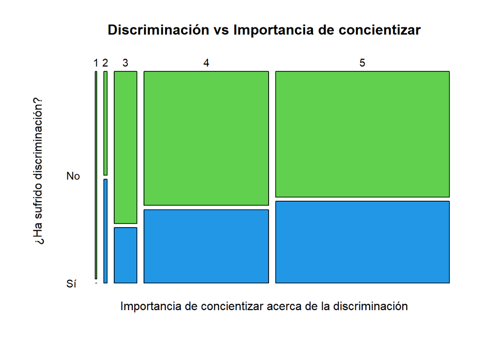

```r
mosaicplot(~Concientizar + HaberSufridoDiscriminacion, data = base_de_datos, color = 3:10, las = 1, cex.axis =0.9, xlab = "Importancia de concientizar acerca de la discriminación", ylab = "¿Ha sufrido discriminación?", main = "Discriminación vs Importancia de concientizar")
```

- Del gráfico de mosaico se puede concluir que en ambos casos, personas discriminadas o no, se cree que concientizar acerca de la discriminación es muy importante (5). También, de las personas que creen que podría ser importante (3), es decir que tienen cierto grado de indiferencia hacia el tema, la mayoría no ha sufrido discriminación. En cuanto a los encuestados que creen que no es nada importante (1), casi ninguno ha sido discriminado. Se podría decir que la mayoría de personas estan a favor de la concientización sobre combatir, sancionar, y erradicar la discriminación.
- **Ha sufrido discriminación - Clase social:** Se estudian las variables ya que pueden estar relacionadas.

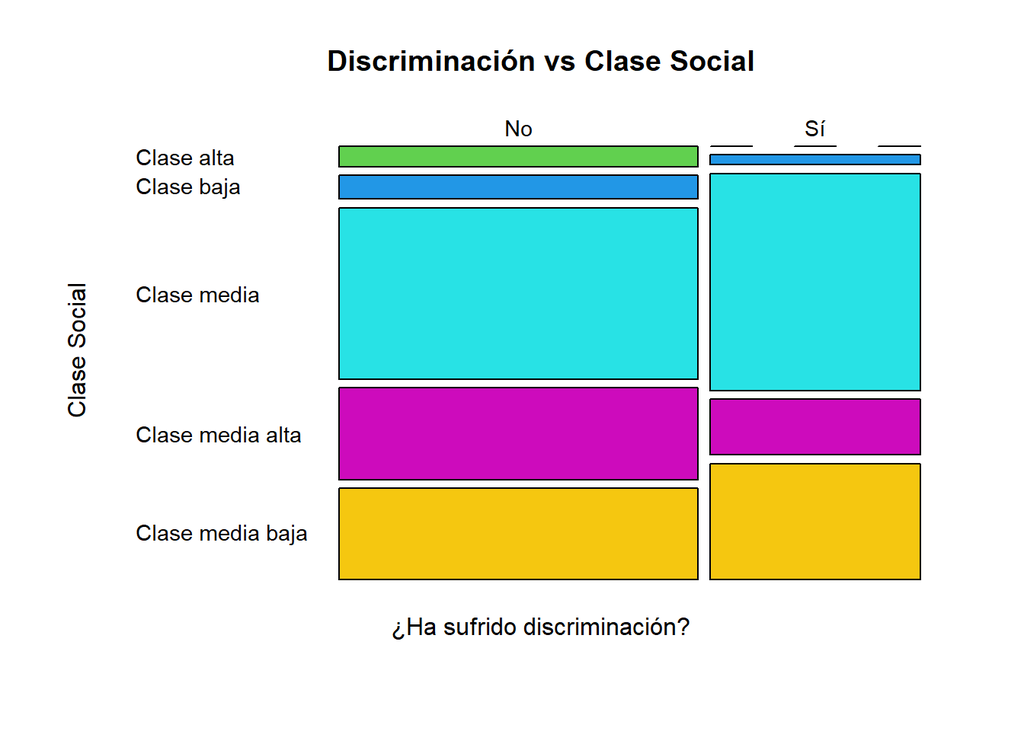

```r
mosaicplot(~HaberSufridoDiscriminacion + ClaseSocial, data = base_de_datos, color = 3:10, las = 1, cex.axis =0.9, ylab = "Clase Social", xlab = "¿Ha sufrido discriminación?", main = "Discriminación vs Clase Social")
```

- Del gráfico de mosaico se puede concluir que la la mayoría de personas que han sido discriminadas se identifican como clase media, seguida de clase media baja. Por otro lado, la clase alta prácticamente no tiene casos de discriminación sufridos. Se puede inferir que la clase social de la persona influye directamente en la discriminación y puede ser un motivo de esta.

# **Análisis probabilístico**

Se desea obtener las probabilidades de ocurrencia de cada evento en cada una de las variables estudiadas.

- **Edad:**
  - Para que las probabilidades de ocurrencia de los eventos de la variable edad sean correctos y tenga sentido el cálculo de cada uno es importante que los datos deben tener una cierta uniformidad. Si no se cumple este requisito, las probabilidades serán muy bajas por cada evento y no serán representativas. Además, se debe tomar en cuenta a todos los participantes del estudio.

| Edad | Probabilidad |
| --- | --- |
| 16 | 0.005 |
| 17 | 0.206 |
| 18 | 0.248 |
| 19 | 0.215 |
| 20 | 0.117 |
| 21 | 0.131 |
| 22 | 0.056 |
| 23 | 0.014 |
| 24 | 0.009 |

```r
round(nrow(filter(base_de_datos, Edad == 16))/length(base_de_datos$Edad),3)
```

```
## [1] 0.005
```

```r
round(nrow(filter(base_de_datos, Edad == 17))/length(base_de_datos$Edad),3)
```

```
## [1] 0.206
```

```r
round(nrow(filter(base_de_datos, Edad == 18))/length(base_de_datos$Edad),3)
```

```
## [1] 0.248
```

```r
round(nrow(filter(base_de_datos, Edad == 19))/length(base_de_datos$Edad),3)
```

```
## [1] 0.215
```

```r
round(nrow(filter(base_de_datos, Edad == 20))/length(base_de_datos$Edad),3)
```

```
## [1] 0.117
```

```r
round(nrow(filter(base_de_datos, Edad == 21))/length(base_de_datos$Edad),3)
```

```
## [1] 0.131
```

```r
round(nrow(filter(base_de_datos, Edad == 22))/length(base_de_datos$Edad),3)
```

```
## [1] 0.056
```

```r
round(nrow(filter(base_de_datos, Edad == 23))/length(base_de_datos$Edad),3)
```

```
## [1] 0.014
```

```r
round(nrow(filter(base_de_datos, Edad == 24))/length(base_de_datos$Edad),3)
```

```
## [1] 0.009
```

- **Ciclo:**
  - Para que las probabilidades de ocurrencia de los eventos de la variable ciclo sean correctos y tenga sentido el cálculo de cada uno es importante que los datos deben encontrarse dentro del rango 1-10. Además, se debe tomar en cuenta a todos los participantes del estudio.

| Ciclo | Probabilidad |
| --- | --- |
| 1 | 0.089 |
| 2 | 0.262 |
| 3 | 0.15 |
| 4 | 0.173 |
| 5 | 0.136 |
| 6 | 0.084 |
| 7 | 0.065 |
| 8 | 0.037 |
| 9 | 0.005 |
| 10 | 0 |

```r
round(nrow(filter(base_de_datos, Ciclo == 1))/length(base_de_datos$Ciclo),3)
```

```
## [1] 0.089
```

```r
round(nrow(filter(base_de_datos, Ciclo == 2))/length(base_de_datos$Ciclo),3)
```

```
## [1] 0.262
```

```r
round(nrow(filter(base_de_datos, Ciclo == 3))/length(base_de_datos$Ciclo),3)
```

```
## [1] 0.15
```

```r
round(nrow(filter(base_de_datos, Ciclo == 4))/length(base_de_datos$Ciclo),3)
```

```
## [1] 0.173
```

```r
round(nrow(filter(base_de_datos, Ciclo == 5))/length(base_de_datos$Ciclo),3)
```

```
## [1] 0.136
```

```r
round(nrow(filter(base_de_datos, Ciclo == 6))/length(base_de_datos$Ciclo),3)
```

```
## [1] 0.084
```

```r
round(nrow(filter(base_de_datos, Ciclo == 7))/length(base_de_datos$Ciclo),3)
```

```
## [1] 0.065
```

```r
round(nrow(filter(base_de_datos, Ciclo == 8))/length(base_de_datos$Ciclo),3)
```

```
## [1] 0.037
```

```r
round(nrow(filter(base_de_datos, Ciclo == 9))/length(base_de_datos$Ciclo),3)
```

```
## [1] 0.005
```

```r
round(nrow(filter(base_de_datos, Ciclo == 10))/length(base_de_datos$Ciclo),3)
```

```
## [1] 0
```

- **Estatura:**
  - Para que las probabilidades de ocurrencia de los eventos de la variable estatura sean correctos y tenga sentido el cálculo de cada uno es importante que se calculen utilizando rangos. Además, se debe tomar en cuenta a todos los participantes del estudio.

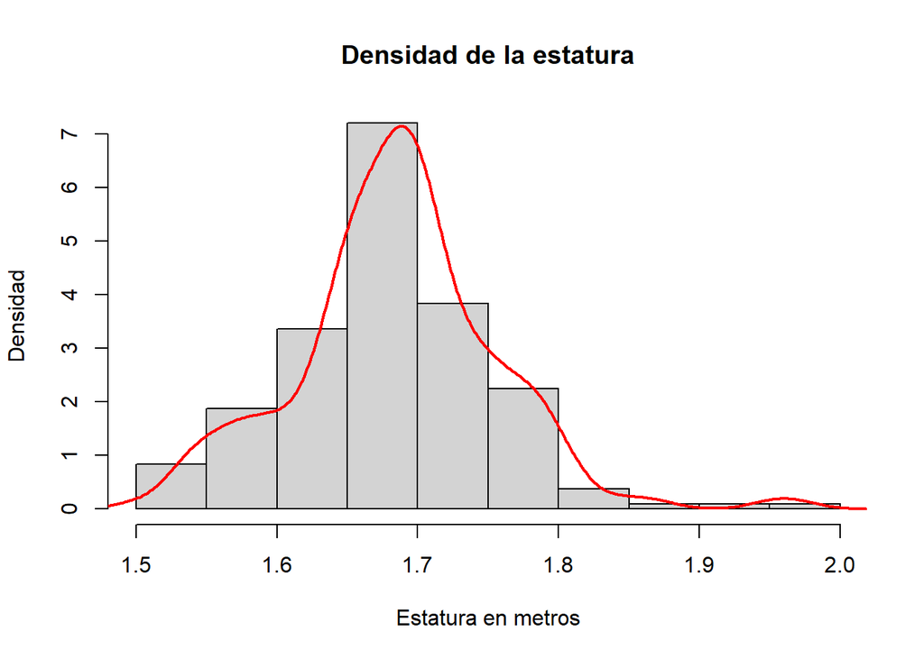

```r
hist(base_de_datos$Estatura, freq = FALSE, main = "Densidad de la estatura",
     ylab = "Densidad",
     xlab = "Estatura en metros")

dx <- density(base_de_datos$Estatura)

lines(dx, lwd = 2, col = "red")
```

Como se puede apreciar en el gráfico, la distribución se asemenja a la distribución normal, por lo que se utlizará esta para calcular las probabilidades.

| Estatura | Probabilidad |
| --- | --- |
| Hasta 1.5m | 0.005 |
| Hasta 1.6m | 0.118 |
| Hasta 1.7m | 0.583 |
| Hasta 1.8m | 0.946 |
| Hasta 1.9m | 0.999 |
| +1.5m | 0.995 |
| +1.6m | 0.882 |
| +1.7m | 0.417 |
| +1.8m | 0.054 |
| +1.9m | 0.001 |

```r
round(pnorm(q = 1.5, mean = mean(base_de_datos$Estatura), sd = sd(base_de_datos$Estatura)),3)
```

```
## [1] 0.005
```

```r
round(pnorm(q = 1.6, mean = mean(base_de_datos$Estatura), sd = sd(base_de_datos$Estatura)),3)
```

```
## [1] 0.118
```

```r
round(pnorm(q = 1.7, mean = mean(base_de_datos$Estatura), sd = sd(base_de_datos$Estatura)),3)
```

```
## [1] 0.583
```

```r
round(pnorm(q = 1.8, mean = mean(base_de_datos$Estatura), sd = sd(base_de_datos$Estatura)),3)
```

```
## [1] 0.946
```

```r
round(pnorm(q = 1.9, mean = mean(base_de_datos$Estatura), sd = sd(base_de_datos$Estatura)),3)
```

```
## [1] 0.999
```

```r
round(1- pnorm(q = 1.5, mean = mean(base_de_datos$Estatura), sd = sd(base_de_datos$Estatura)),3)
```

```
## [1] 0.995
```

```r
round(1- pnorm(q = 1.6, mean = mean(base_de_datos$Estatura), sd = sd(base_de_datos$Estatura)),3)
```

```
## [1] 0.882
```

```r
round(1- pnorm(q = 1.7, mean = mean(base_de_datos$Estatura), sd = sd(base_de_datos$Estatura)),3)
```

```
## [1] 0.417
```

```r
round(1- pnorm(q = 1.8, mean = mean(base_de_datos$Estatura), sd = sd(base_de_datos$Estatura)),3)
```

```
## [1] 0.054
```

```r
round(1- pnorm(q = 1.9, mean = mean(base_de_datos$Estatura), sd = sd(base_de_datos$Estatura)),3)
```

```
## [1] 0.001
```

- **Peso:**
  - Para que las probabilidades de ocurrencia de los eventos de la variable estatura sean correctos y tenga sentido el cálculo de cada uno es importante que se calculen utilizando rangos. Además, se debe tomar en cuenta a todos los participantes del estudio.

| Peso | Probabilidad |
| --- | --- |
| 51-60kg | 0.243 |
| 61-70kg | 0.238 |
| 71-80kg | 0.294 |
| 81-90kg | 0.159 |
| 91-100kg | 0.023 |
| 101-120kg | 0.005 |

```r
round(nrow(filter(base_de_datos, Peso  <= 60, Peso > 50))/length(base_de_datos$Peso),3)
```

```
## [1] 0.243
```

```r
round(nrow(filter(base_de_datos, Peso <= 70, Peso > 60))/length(base_de_datos$Peso),3)
```

```
## [1] 0.238
```

```r
round(nrow(filter(base_de_datos, Peso <= 80, Peso > 70))/length(base_de_datos$Peso),3)
```

```
## [1] 0.294
```

```r
round(nrow(filter(base_de_datos, Peso <= 90, Peso > 80))/length(base_de_datos$Peso),3)
```

```
## [1] 0.159
```

```r
round(nrow(filter(base_de_datos, Peso <= 100, Peso > 90))/length(base_de_datos$Peso),3)
```

```
## [1] 0.023
```

```r
round(nrow(filter(base_de_datos, Peso <= 120, Peso > 100))/length(base_de_datos$Peso),3)
```

```
## [1] 0.005
```

- **Sexo:**
  - Para que las probabilidades de ocurrencia de los eventos de la variable sexo sean correctos y tenga sentido el cálculo de cada uno es importante que se tome en cuenta el contexto del estudio, es decir, que este fue realizado en la universidad UTEC ubicada en Lima, Perú. Además, se debe tomar en cuenta a todos los participantes del estudio.

| Sexo | Probabilidad |
| --- | --- |
| Hombre | 0.65 |
| Mujer | 0.35 |

```r
round(nrow(filter(base_de_datos, Sexo == "Hombre"))/length(base_de_datos$Sexo),2)
```

```
## [1] 0.65
```

```r
round(nrow(filter(base_de_datos, Sexo == "Mujer"))/length(base_de_datos$Sexo),2)
```

```
## [1] 0.35
```

- **Distrito de residencia:**
  - Para que las probabilidades de ocurrencia de los eventos de la variable distrito de residencia sean correctos y tenga sentido el cálculo de cada uno es importante que se tome en cuenta el contexto del estudio. Además, se debe tomar en cuenta a todos los participantes del estudio.

[output not shown]

```r
round(nrow(filter(base_de_datos, Distrito == "Surquillo"))/length(base_de_datos$Distrito),3)
```

```
## [1] 0.023
```

```r
round(nrow(filter(base_de_datos, Distrito == "San Juan de Lurigancho"))/length(base_de_datos$Distrito),3)
```

```
## [1] 0.098
```

```r
round(nrow(filter(base_de_datos, Distrito == "Miraflores"))/length(base_de_datos$Distrito),3)
```

```
## [1] 0.084
```

```r
round(nrow(filter(base_de_datos, Distrito == "Jesús María"))/length(base_de_datos$Distrito),3)
```

```
## [1] 0.028
```

```r
round(nrow(filter(base_de_datos, Distrito == "Chorrillos"))/length(base_de_datos$Distrito),3)
```

```
## [1] 0.075
```

```r
round(nrow(filter(base_de_datos, Distrito == "Santiago de Surco"))/length(base_de_datos$Distrito),3)
```

```
## [1] 0.079
```

```r
round(nrow(filter(base_de_datos, Distrito == "Pueblo Libre"))/length(base_de_datos$Distrito),3)
```

```
## [1] 0.009
```

```r
round(nrow(filter(base_de_datos, Distrito == "Ate Vitarte"))/length(base_de_datos$Distrito),3)
```

```
## [1] 0.014
```

```r
round(nrow(filter(base_de_datos, Distrito == "Santa Anita"))/length(base_de_datos$Distrito),3)
```

```
## [1] 0.009
```

```r
round(nrow(filter(base_de_datos, Distrito == "Lurigancho"))/length(base_de_datos$Distrito),3)
```

```
## [1] 0.005
```

```r
round(nrow(filter(base_de_datos, Distrito == "San Juan de Miraflores"))/length(base_de_datos$Distrito),3)
```

```
## [1] 0.023
```

```r
round(nrow(filter(base_de_datos, Distrito == "San Borja"))/length(base_de_datos$Distrito),3)
```

```
## [1] 0.023
```

```r
round(nrow(filter(base_de_datos, Distrito == "San Isidro"))/length(base_de_datos$Distrito),3)
```

```
## [1] 0.037
```

```r
round(nrow(filter(base_de_datos, Distrito == "Provincia"))/length(base_de_datos$Distrito),3)
```

```
## [1] 0.005
```

```r
round(nrow(filter(base_de_datos, Distrito == "Independencia"))/length(base_de_datos$Distrito),3)
```

```
## [1] 0.009
```

```r
round(nrow(filter(base_de_datos, Distrito == "San Miguel"))/length(base_de_datos$Distrito),3)
```

```
## [1] 0.023
```

```r
round(nrow(filter(base_de_datos, Distrito == "Barranco"))/length(base_de_datos$Distrito),3)
```

```
## [1] 0.061
```

```r
round(nrow(filter(base_de_datos, Distrito == "San Luis"))/length(base_de_datos$Distrito),3)
```

```
## [1] 0.005
```

```r
round(nrow(filter(base_de_datos, Distrito == "Lurín"))/length(base_de_datos$Distrito),3)
```

```
## [1] 0.028
```

```r
round(nrow(filter(base_de_datos, Distrito == "Los Olivos"))/length(base_de_datos$Distrito),3)
```

```
## [1] 0.056
```

```r
round(nrow(filter(base_de_datos, Distrito == "Lima"))/length(base_de_datos$Distrito),3)
```

```
## [1] 0.005
```

```r
round(nrow(filter(base_de_datos, Distrito == "La Molina"))/length(base_de_datos$Distrito),3)
```

```
## [1] 0.033
```

```r
round(nrow(filter(base_de_datos, Distrito == "Ancón"))/length(base_de_datos$Distrito),3)
```

```
## [1] 0.005
```

```r
round(nrow(filter(base_de_datos, Distrito == "Comas"))/length(base_de_datos$Distrito),3)
```

```
## [1] 0.028
```

```r
round(nrow(filter(base_de_datos, Distrito == "Lince"))/length(base_de_datos$Distrito),3)
```

```
## [1] 0.028
```

```r
round(nrow(filter(base_de_datos, Distrito == "El Agustino"))/length(base_de_datos$Distrito),3)
```

```
## [1] 0.019
```

```r
round(nrow(filter(base_de_datos, Distrito == "Magdalena del Mar"))/length(base_de_datos$Distrito),3)
```

```
## [1] 0.014
```

```r
round(nrow(filter(base_de_datos, Distrito == "Pachacamac"))/length(base_de_datos$Distrito),3)
```

```
## [1] 0.014
```

```r
round(nrow(filter(base_de_datos, Distrito == "Breña"))/length(base_de_datos$Distrito),3)
```

```
## [1] 0.023
```

```r
round(nrow(filter(base_de_datos, Distrito == "La Victoria"))/length(base_de_datos$Distrito),3)
```

```
## [1] 0.009
```

```r
round(nrow(filter(base_de_datos, Distrito == "Pucusana"))/length(base_de_datos$Distrito),3)
```

```
## [1] 0.005
```

```r
round(nrow(filter(base_de_datos, Distrito == "Villa El Salvador"))/length(base_de_datos$Distrito),3)
```

```
## [1] 0.042
```

```r
round(nrow(filter(base_de_datos, Distrito == "Villa María del Triunfo"))/length(base_de_datos$Distrito),3)
```

```
## [1] 0.014
```

```r
round(nrow(filter(base_de_datos, Distrito == "Cieneguilla"))/length(base_de_datos$Distrito),3)
```

```
## [1] 0.009
```

```r
round(nrow(filter(base_de_datos, Distrito == "Carabayllo"))/length(base_de_datos$Distrito),3)
```

```
## [1] 0.005
```

```r
round(nrow(filter(base_de_datos, Distrito == "Rímac"))/length(base_de_datos$Distrito),3)
```

```
## [1] 0.009
```

```r
round(nrow(filter(base_de_datos, Distrito == "Puente Piedra"))/length(base_de_datos$Distrito),3)
```

```
## [1] 0.009
```

```r
round(nrow(filter(base_de_datos, Distrito == "San Martín de Porres"))/length(base_de_datos$Distrito),3)
```

```
## [1] 0.033
```

- **Clase social**
  - Para que las probabilidades de ocurrencia de los eventos de la variable clase social sean correctos y tenga sentido el cálculo de cada uno es importante que se tome en cuenta el contexto del estudio, es decir, que este fue realizado en la universidad UTEC ubicada en Lima, Perú. Además, se debe tomar en cuenta a todos los participantes del estudio.

| Clase social | Probabilidad |
| --- | --- |
| Clase alta | 0.03 |
| Clase media alta | 0.2 |
| Clase media | 0.47 |
| Clase media baja | 0.25 |
| Clase baja | 0.05 |

```r
round(nrow(filter(base_de_datos, ClaseSocial == "Clase baja"))/length(base_de_datos$ClaseSocial),2)
```

```
## [1] 0.05
```

```r
round(nrow(filter(base_de_datos, ClaseSocial == "Clase media baja"))/length(base_de_datos$ClaseSocial),2)
```

```
## [1] 0.25
```

```r
round(nrow(filter(base_de_datos, ClaseSocial == "Clase media"))/length(base_de_datos$ClaseSocial),2)
```

```
## [1] 0.47
```

```r
round(nrow(filter(base_de_datos, ClaseSocial == "Clase media alta"))/length(base_de_datos$ClaseSocial),2)
```

```
## [1] 0.2
```

```r
round(nrow(filter(base_de_datos, ClaseSocial == "Clase alta"))/length(base_de_datos$ClaseSocial),2)
```

```
## [1] 0.03
```

- **Haber sufrido discriminación**
  - Para que las probabilidades de ocurrencia de los eventos de la variable haber sufrido discriminación sean correctos y tenga sentido el cálculo de cada uno es importante que se tome en cuenta el contexto del estudio.

| Haber sufrido discriminación | Probabilidad |
| --- | --- |
| Sí | 0.37 |
| No | 0.63 |

```r
round(nrow(filter(base_de_datos, HaberSufridoDiscriminacion == "Sí"))/length(base_de_datos$HaberSufridoDiscriminacion),2)
```

```
## [1] 0.37
```

```r
round(nrow(filter(base_de_datos, HaberSufridoDiscriminacion == "No"))/length(base_de_datos$HaberSufridoDiscriminacion),2)
```

```
## [1] 0.63
```

- **Forma de discriminación**
  - Para que las probabilidades de ocurrencia de los eventos de la variable forma de discriminación sean correctos y tenga sentido el cálculo de cada uno es importante que solo se tomen en cuenta a las personas que sí sufrieron discriminación.

| Forma de discriminación | Probabilidad |
| --- | --- |
| Verbal | 0.709 |
| Física | 0.051 |
| Exclusión | 0.215 |
| Mediante redes sociales | 0.013 |

```r
x <- filter(base_de_datos, HaberSufridoDiscriminacion == "Sí")

round(nrow(filter(base_de_datos, Formadediscriminacion == "Verbal"))/nrow(x),3)
```

```
## [1] 0.709
```

```r
round(nrow(filter(base_de_datos, Formadediscriminacion == "Física"))/nrow(x),3)
```

```
## [1] 0.051
```

```r
round(nrow(filter(base_de_datos, Formadediscriminacion == "Exclusión"))/nrow(x),3)
```

```
## [1] 0.215
```

```r
round(nrow(filter(base_de_datos, Formadediscriminacion == "Mediante redes sociales"))/nrow(x),3)
```

```
## [1] 0.013
```

- **Motivo del acto discriminatorio**
  - Para que las probabilidades de ocurrencia de los eventos de la variable forma de discriminación sean correctos y tenga sentido el cálculo de cada uno es importante que solo se tomen en cuenta a las personas que sí sufrieron discriminación.

| Motivo | Probabilidad |
| --- | --- |
| Lugar de origen | 0.101 |
| Aspecto físico | 0.506 |
| Religión | 0.051 |
| Estatus social | 0.025 |
| Estatus económico | 0.089 |
| Enfermedad | 0.013 |
| Orientación sexual | 0.063 |
| Sexo | 0.063 |
| Lugar de residencia | 0.076 |
| Embarazo | 0.013 |

```r
round(nrow(filter(base_de_datos, MotivodelActoDiscriminatorio == "Lugar de origen"))/nrow(x),3)
```

```
## [1] 0.101
```

```r
round(nrow(filter(base_de_datos, MotivodelActoDiscriminatorio == "Aspecto físico"))/nrow(x),3)
```

```
## [1] 0.506
```

```r
round(nrow(filter(base_de_datos, MotivodelActoDiscriminatorio == "Religión"))/nrow(x),3)
```

```
## [1] 0.051
```

```r
round(nrow(filter(base_de_datos, MotivodelActoDiscriminatorio == "Estatus social"))/nrow(x),3)
```

```
## [1] 0.025
```

```r
round(nrow(filter(base_de_datos, MotivodelActoDiscriminatorio == "Estatus económico"))/nrow(x),3)
```

```
## [1] 0.089
```

```r
round(nrow(filter(base_de_datos, MotivodelActoDiscriminatorio == "Enfermedad"))/nrow(x),3)
```

```
## [1] 0.013
```

```r
round(nrow(filter(base_de_datos, MotivodelActoDiscriminatorio == "Orientación sexual"))/nrow(x),3)
```

```
## [1] 0.063
```

```r
round(nrow(filter(base_de_datos, MotivodelActoDiscriminatorio == "Sexo"))/nrow(x),3)
```

```
## [1] 0.063
```

```r
round(nrow(filter(base_de_datos, MotivodelActoDiscriminatorio == "Lugar de residencia"))/nrow(x),3)
```

```
## [1] 0.076
```

```r
round(nrow(filter(base_de_datos, MotivodelActoDiscriminatorio == "Embarazo"))/nrow(x),3)
```

```
## [1] 0.013
```

- **Apoyo externo**
  - Para que las probabilidades de ocurrencia de los eventos de la variable forma de discriminación sean correctos y tenga sentido el cálculo de cada uno es importante que solo se tomen en cuenta a las personas que sí sufrieron discriminación.

| Apoyo externo | Probabilidad |
| --- | --- |
| Sí | 0.32 |
| No | 0.68 |

```r
round(nrow(filter(base_de_datos, ApoyoExterno == "Si"))/nrow(x),2)
```

```
## [1] 0.32
```

```r
round(nrow(filter(base_de_datos, ApoyoExterno == "No"))/nrow(x),2)
```

```
## [1] 0.68
```

- **Grado de satisfacción con amigos en UTEC:**
  - Para que las probabilidades de ocurrencia de los eventos de la variable forma de discriminación sean correctos y tenga sentido el cálculo de cada uno es importante que se tomen en cuenta a todas las personas del estudio y se tenga en consideración que no hubo caso del evento “2”. Además, se debe tomar en cuenta a todos los participantes del estudio.

| Grado de satisfacción | Probabilidad |
| --- | --- |
| 1 | 0.014 |
| 2 | 0 |
| 3 | 0.061 |
| 4 | 0.505 |
| 5 | 0.421 |

```r
round(nrow(filter(base_de_datos, GradoSatisfaccionAmigos == "1"))/length(base_de_datos$GradoSatisfaccionAmigos),3)
```

```
## [1] 0.014
```

```r
round(nrow(filter(base_de_datos, GradoSatisfaccionAmigos == "2"))/length(base_de_datos$GradoSatisfaccionAmigos),3)
```

```
## [1] 0
```

```r
round(nrow(filter(base_de_datos, GradoSatisfaccionAmigos == "3"))/length(base_de_datos$GradoSatisfaccionAmigos),3)
```

```
## [1] 0.061
```

```r
round(nrow(filter(base_de_datos, GradoSatisfaccionAmigos == "4"))/length(base_de_datos$GradoSatisfaccionAmigos),3)
```

```
## [1] 0.505
```

```r
round(nrow(filter(base_de_datos, GradoSatisfaccionAmigos == "5"))/length(base_de_datos$GradoSatisfaccionAmigos),3)
```

```
## [1] 0.421
```

- **Cree la persona que la discriminación dentro de la universidad puede llevar al afectado a un mal rendimiento académico:**
  - Para que las probabilidades de ocurrencia de los eventos de la variable cree la persona que la discriminación dentro de la universidad puede llevar al afectado a un mal rendimiento académico sean correctos y tenga sentido el cálculo de cada uno es importante que se tome en cuenta que el estudio fue realizado mediante encuestas a alumnos de la universidad UTEC, la cual es de alta exigencia académica. Además, se debe tomar en cuenta a todos los participantes del estudio.

| ¿Puede afectar al rendimiento académico? | Probabilidad |
| --- | --- |
| Sí | 0.879 |
| No | 0.121 |

```r
round(nrow(filter(base_de_datos, AfectaRendimiento == "Si"))/length(base_de_datos$AfectaRendimiento),3)
```

```
## [1] 0.879
```

```r
round(nrow(filter(base_de_datos, AfectaRendimiento == "No"))/length(base_de_datos$AfectaRendimiento),3)
```

```
## [1] 0.121
```

- **Importancia de concientizar acerca de la discriminación:**
  - Para que las probabilidades de ocurrencia de los eventos de la variable importancia de concientizar acerca de la discriminación sean correctos y tenga sentido el cálculo de cada uno es importante que se tome en cuenta que el estudio fue realizado mediante encuestas a alumnos de la universidad UTEC, la cual cuenta con acción continua frente a la discriminación. Además, se debe tomar en cuenta a todos los participantes del estudio.

| Importancia de concientizar | Probabilidad |
| --- | --- |
| 1 | 0.005 |
| 2 | 0 009 |
| 3 | 0.070 |
| 4 | 0.383 |
| 5 | 0.533 |

```r
round(nrow(filter(base_de_datos, Concientizar == "1"))/length(base_de_datos$Concientizar),3)
```

```
## [1] 0.005
```

```r
round(nrow(filter(base_de_datos, Concientizar == "2"))/length(base_de_datos$Concientizar),3)
```

```
## [1] 0.009
```

```r
round(nrow(filter(base_de_datos, Concientizar == "3"))/length(base_de_datos$Concientizar),3)
```

```
## [1] 0.07
```

```r
round(nrow(filter(base_de_datos, Concientizar == "4"))/length(base_de_datos$Concientizar),3)
```

```
## [1] 0.383
```

```r
round(nrow(filter(base_de_datos, Concientizar == "5"))/length(base_de_datos$Concientizar),3)
```

```
## [1] 0.533
```

- **Ha sufrido discriminción - Peso:**

```r
o <- filter(base_de_datos, HaberSufridoDiscriminacion == "Sí")
round(nrow(filter(o, Peso  <= 60, Peso > 50))/nrow(o),3)
```

```
## [1] 0.241
```

```r
round(nrow(filter(o, Peso <= 70, Peso > 60))/nrow(o),3)
```

```
## [1] 0.304
```

```r
round(nrow(filter(o, Peso <= 80, Peso > 70))/nrow(o),3)
```

```
## [1] 0.291
```

```r
round(nrow(filter(o, Peso <= 90, Peso > 80))/nrow(o),3)
```

```
## [1] 0.114
```

```r
round(nrow(filter(o, Peso <= 100, Peso > 90))/nrow(o),3)
```

```
## [1] 0.051
```

- Se puede inferir que hay mayor densidad y probabilidad de casos de discriminación entre las personas que pesan más de 65-70 kg.
- **Ha sufrido discriminación - Importancia de concientizar acerca de la discriminación:**

```r
a <- filter(base_de_datos, HaberSufridoDiscriminacion == "No")
round(nrow(filter(o, Concientizar == 5))/nrow(o),3)
```

```
## [1] 0.57
```

```r
round(nrow(filter(a, Concientizar == 5))/nrow(a),3)
```

```
## [1] 0.511
```

- Se puede concluir que hay más probabilidades de creer que es importante concientizar acerca de la discriminación si se ha experimentado esta situación.
- **Ha sufrido discriminación - Clase social:**

```r
w = filter(base_de_datos, ClaseSocial == "Clase alta")
e = filter(base_de_datos, ClaseSocial == "Clase media")
d = filter(base_de_datos, ClaseSocial == "Clase media baja")
round(nrow(filter(w, HaberSufridoDiscriminacion == "Sí"))/nrow(w),3)
```

```
## [1] 0
```

```r
round(nrow(filter(e, HaberSufridoDiscriminacion == "Sí"))/nrow(e),3)
```

```
## [1] 0.426
```

```r
round(nrow(filter(d, HaberSufridoDiscriminacion == "Sí"))/nrow(d),3)
```

```
## [1] 0.426
```

- Se puede concluir que hay más probabilidades de sufrir discriminación perteneciendo a la clase media o media baja que la a clase alta.

## Modelos:

### Distribución Geométrica

Utilizando un modelo de distribución geométrica se desea responder a la pregunta: ¿Qué probabilidad hay de encontrar a una persona que haya sufrido discriminación depués de x que no?. Mediante esta pregunta se desea analizar la frecuencia de los casos de discriminación recogidos por el estudio.

El éxito será considerado como una persona que sí halla sufrido discriminación mientras que otros casos serán fracasos. Para hallar la probabilidad (P) de éxito se realiza lo siguiente:

```r
round(prop.table(table(base_de_datos$HaberSufridoDiscriminacion)),2)
```

```
##
##   No   Sí
## 0.63 0.37
```

Se determina que P = 0.37, x = número de fracasos antes del éxito, y el espacio muestral todas las personas encuestadas para el estudio.

Antes de realizar los cálculos se grafica la distribución geométrica de la variable:

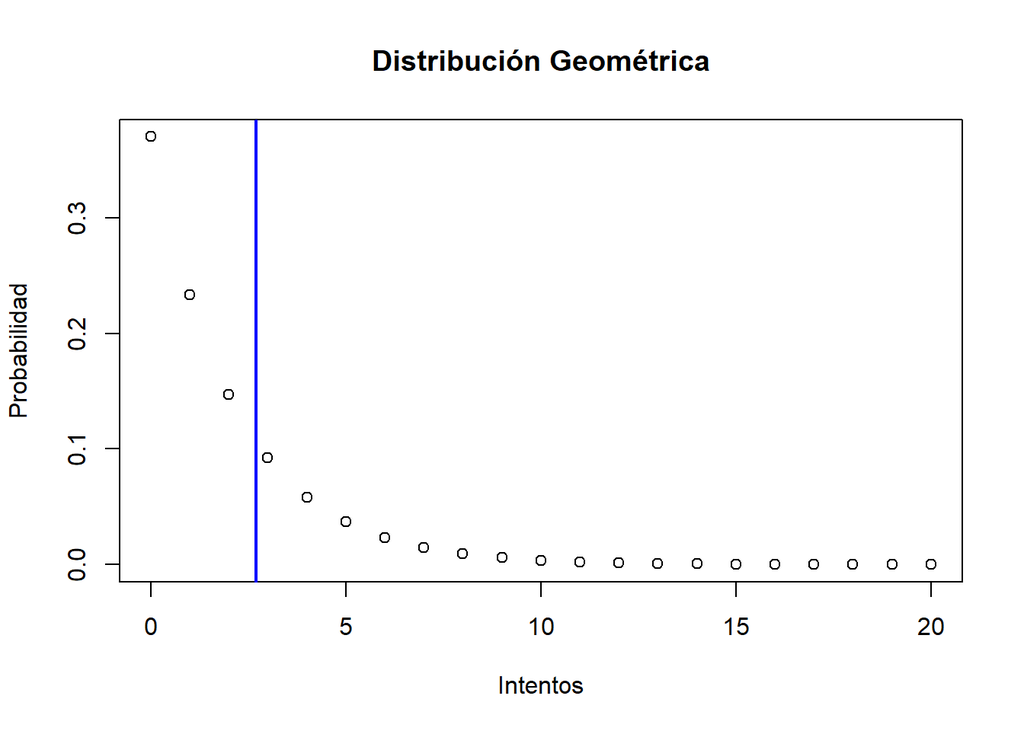

```
## integer(0)
```

```r
plot(x=c(0:20), y=dgeom(x=c(0:20), prob=0.37), xlab = "Intentos", ylab = "Probabilidad", main = "Distribución Geométrica") + abline(v= 1/0.37, col="blue", lwd=2)
```

```r
1/0.37
```

```
## [1] 2.702703
```

Se puede observar que la esperanza está en 2.7 intentos por lo que este será el intento promedio en el que encontraremos a una persona que ha sido discriminada.

Se realizan los cálculos para x = (1,3,9,11,19):

```r
dgeom(x = 1, prob = 0.37)
```

```
## [1] 0.2331
```

```r
dgeom(x = 3, prob = 0.37)
```

```
## [1] 0.09251739
```

```r
dgeom(x = 9, prob = 0.37)
```

```
## [1] 0.005784511
```

```r
dgeom(x = 11, prob = 0.37)
```

```
## [1] 0.002295873
```

```r
dgeom(x = 19, prob = 0.37)
```

```
## [1] 5.69734e-05
```

Se puede concluir que mientras mayor sea el número de personas que no han sufrido discriminación menor será la probabilidad de encontrar una que sí.

### Distribución Normal

Utilizando un modelo de distribución normal se desea responder a la pregunta: ¿Cuál es la probabilidad de que una persona que ha sufrido discriminación mida menos de x metros?

Se eligió el modelo ya que como se observa en la gráfica la variable guarda cierta similitud con la distribución normal.

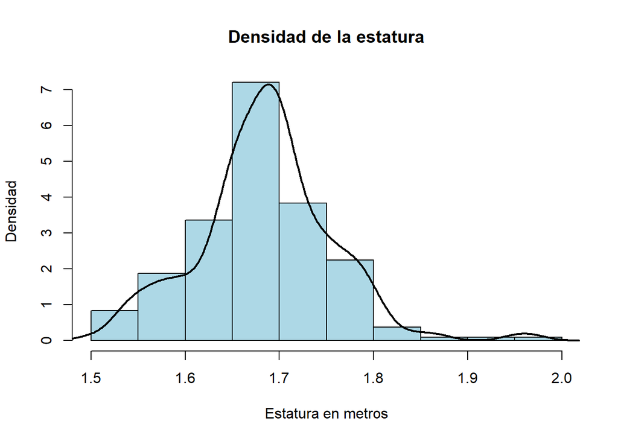

```r
hist(base_de_datos$Estatura, freq = FALSE, main = "Densidad de la estatura",
     ylab = "Densidad",
     xlab = "Estatura en metros",
     col = "lightblue")

dx <- density(base_de_datos$Estatura)

lines(dx, lwd = 2, col = "black")
```

```r
mfv(base_de_datos$Estatura)
```

```
## [1] 1.7
```

```r
median(base_de_datos$Estatura)
```

```
## [1] 1.68
```

```r
mean(base_de_datos$Estatura)
```

```
## [1] 1.685
```

Además, la moda, media y mediana se encuentran en el mismo intervalo.

Para realizar los cálculos se hallar la desviación estándar y media de la variable estatura de las personas que han sufrido discriminación:

```r
x <- filter(base_de_datos, HaberSufridoDiscriminacion == "Sí")
mean(x$Estatura)
```

```
## [1] 1.681013
```

```r
sd(x$Estatura)
```

```
## [1] 0.06546863
```

Se realizan los cálculos para x = (1.6,1.7,1.8)

```r
pnorm(q = 1.6, mean = 1.681013, sd = 0.06546863)
```

```
## [1] 0.1079633
```

```r
pnorm(q = 1.7, mean = 1.681013, sd = 0.06546863)
```

```
## [1] 0.6140983
```

```r
pnorm(q = 1.8, mean = 1.681013, sd = 0.06546863)
```

```
## [1] 0.9654271
```

Se puede concluir que en el caso de este estudio, la estatura no ha sido un factor determinante en las situaciones de discriminación. Se puede inferir que los casos de discriminación por aspecto físico tienden a ser por el color de piel, origen étnico, o incluso peso.

### Distribución Hipergeométrica

Se eligió el modelo ya que como se observa en el gráfico la distribución de la variable edad se asemeja a la distribución hypergeométrica.

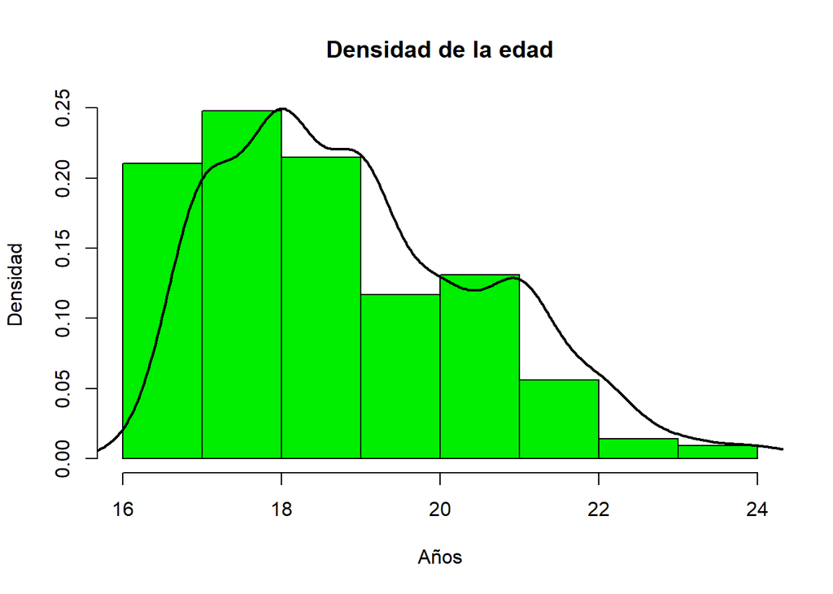

```r
hist(base_de_datos$Edad, freq = FALSE, main = "Densidad de la edad",
     ylab = "Densidad",
     xlab = "Años",
     col = "green2")

dx <- density(base_de_datos$Edad)

lines(dx, lwd = 2, col = "black")
```

Para realizar los cálculos se hallará la cantidad de personas que hayan sido discriminadas y que tengan 18, 19 y 20 años:

```r
i <- filter(base_de_datos, HaberSufridoDiscriminacion == "Sí")
nrow(filter(i, Edad == 18))
```

```
## [1] 23
```

```r
nrow(filter(i, Edad == 19))
```

```
## [1] 17
```

```r
nrow(filter(i, Edad == 20))
```

```
## [1] 10
```

Se obtiene m (cantidad de éxitos) y n (cantidad de fracasos). Además, se sabe que k = 3.

Se realizan los cálculos para x = (18,19,20):

```r
1 - phyper(q = 1, m = 23, n = nrow(i) - 23, k = 3)
```

```
## [1] 0.2015579
```

```r
1 - phyper(q = 1, m = 17, n = nrow(i) - 23, k = 3)
```

```
## [1] 0.1333848
```

```r
1 - phyper(q = 1, m = 10, n = nrow(i) - 23, k = 3)
```

```
## [1] 0.05769231
```

Se puede concluir que hay más casos de discriminación en las personas de 18 años al realizar un experimento en una universidad, donde el rango de edad es conocido.

# **Bibliografía**

- Ross, M. (2014). Introduction to Probability and Statistics for Engineers and Scientists. Academic Press.
- R - Normal Distribution. (s. f.). R - Normal Distribution. Recuperado 25 de noviembre de 2022, de https://www.tutorialspoint.com/r/r_normal_distribution.htm
- Peng, R. (2019). R Programming for Data Science [Archivo PDF]. https://leanpub.com/rprogramming